# Проект №2

10/10/2020

# 1 Описание данных

Я буду использовать данные о ценности жилья в бостоне в 1970-1980-х годах. В данных представлены следующие переменные:

```
CRIM - per capita crime rate by town
ZN - proportion of residential land zoned for lots over 25,000 sq.ft.
INDUS - proportion of non-retail business acres per town.
CHAS - Charles River dummy variable (1 if tract bounds river; 0 otherwise)
NOX - nitric oxides concentration (parts per 10 million)
RM - average number of rooms per dwelling
AGE - proportion of owner-occupied units built prior to 1940
DIS - weighted distances to five Boston employment centres
RAD - index of accessibility to radial highways
TAX - full-value property-tax rate per $10,000
PTRATIO - pupil-teacher ratio by town
B - 1000(Bk - 0.63)^2 where Bk is the proportion of blacks by town
LSTAT - % lower status of the population
MEDV - Median value of owner-occupied homes in $1000's
```

Переменные chas и rad являются факторными.

```r
data("Boston")
Boston$chas <- factor(Boston$chas)
Boston$rad <- factor(Boston$rad)
str(Boston)
```

```
## 'data.frame':    506 obs. of  14 variables:
##  $ crim   : num  0.00632 0.02731 0.02729 0.03237 0.06905 ...
##  $ zn     : num  18 0 0 0 0 0 12.5 12.5 12.5 12.5 ...
##  $ indus  : num  2.31 7.07 7.07 2.18 2.18 2.18 7.87 7.87 7.87 7.87 ...
##  $ chas   : Factor w/ 2 levels "0","1": 1 1 1 1 1 1 1 1 1 1 ...
##  $ nox    : num  0.538 0.469 0.469 0.458 0.458 0.458 0.524 0.524 0.524 0.524 ...
##  $ rm     : num  6.58 6.42 7.18 7 7.15 ...
##  $ age    : num  65.2 78.9 61.1 45.8 54.2 58.7 66.6 96.1 100 85.9 ...
##  $ dis    : num  4.09 4.97 4.97 6.06 6.06 ...
##  $ rad    : Factor w/ 9 levels "1","2","3","4",..: 1 2 2 3 3 3 5 5 5 5 ...
##  $ tax    : num  296 242 242 222 222 222 311 311 311 311 ...
##  $ ptratio: num  15.3 17.8 17.8 18.7 18.7 18.7 15.2 15.2 15.2 15.2 ...
##  $ black  : num  397 397 393 395 397 ...
##  $ lstat  : num  4.98 9.14 4.03 2.94 5.33 ...
##  $ medv   : num  24 21.6 34.7 33.4 36.2 28.7 22.9 27.1 16.5 18.9 ...
```

Поскольку переменные представлены в различных величинах, для построения модели необходимо стандартизовать предикторы. Это позволит наиболее объективно сравнивать вклад различных предикторов в объяснение изменчивости.

```r
Boston[, -c(4,9,14)] <- as.data.frame(apply(Boston[,-c(4,9,14)], 2, scale))
```

# 2 Исследование полной линейной модели

## 2.1 Построение модели

Построим полную линейную модель без взаимодействия предикторов.

```r
model <- lm(medv ~ crim + zn + indus + chas + nox + rm + age + dis + rad + tax + ptratio + black + lstat, data=Boston)
summary(model)
```

```
##
## Call:
## lm(formula = medv ~ crim + zn + indus + chas + nox + rm + age +
##     dis + rad + tax + ptratio + black + lstat, data = Boston)
##
## Residuals:
##      Min       1Q   Median       3Q      Max
## -15.1020  -2.7355  -0.4565   1.6821  25.9450
##
## Coefficients:
##             Estimate Std. Error t value Pr(>|t|)
## (Intercept) 18.31176    1.15474  15.858  < 2e-16 ***
## crim        -0.93603    0.28114  -3.329 0.000937 ***
## zn           1.28032    0.32999   3.880 0.000119 ***
## indus        0.16300    0.43665   0.373 0.709081
## chas1        2.52416    0.86318   2.924 0.003614 **
## nox         -2.03633    0.45150  -4.510 8.13e-06 ***
## rm           2.57544    0.29594   8.703  < 2e-16 ***
## age          0.01298    0.37232   0.035 0.972210
## dis         -3.27342    0.42516  -7.699 7.75e-14 ***
## rad2         1.48891    1.47751   1.008 0.314095
## rad3         4.68125    1.33530   3.506 0.000498 ***
## rad4         2.57623    1.18737   2.170 0.030514 *
## rad5         2.91849    1.20761   2.417 0.016028 *
## rad6         1.18584    1.46401   0.810 0.418342
## rad7         4.87899    1.57120   3.105 0.002012 **
## rad8         4.83984    1.49166   3.245 0.001257 **
## rad24        7.46167    1.78868   4.172 3.58e-05 ***
## tax         -1.47439    0.65641  -2.246 0.025144 *
## ptratio     -2.10523    0.31279  -6.731 4.78e-11 ***
## black        0.85761    0.24291   3.531 0.000454 ***
## lstat       -3.77923    0.36162 -10.451  < 2e-16 ***
## ---
## Signif. codes:  0 '***' 0.001 '**' 0.01 '*' 0.05 '.' 0.1 ' ' 1
##
## Residual standard error: 4.694 on 485 degrees of freedom
## Multiple R-squared:  0.7499, Adjusted R-squared:  0.7396
## F-statistic:  72.7 on 20 and 485 DF,  p-value: < 2.2e-16
```

## 2.2 Диагностика модели

### 2.2.1 Проверка на наличие влиятельных наблюдений

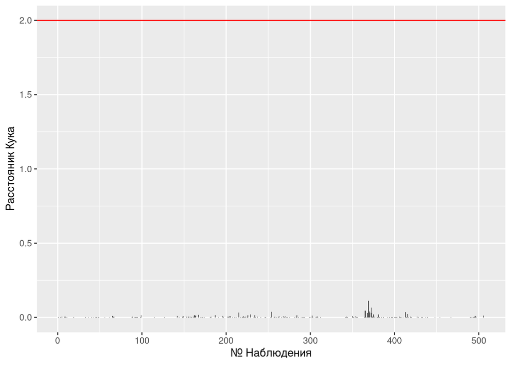

Рисунок 1. График расстояний Кука для полной модели

Из графика видно, что влиятельных наблюдений нет.

### 2.2.2 Проверка на гомогенность дисперсии и линейность взаимосвязи

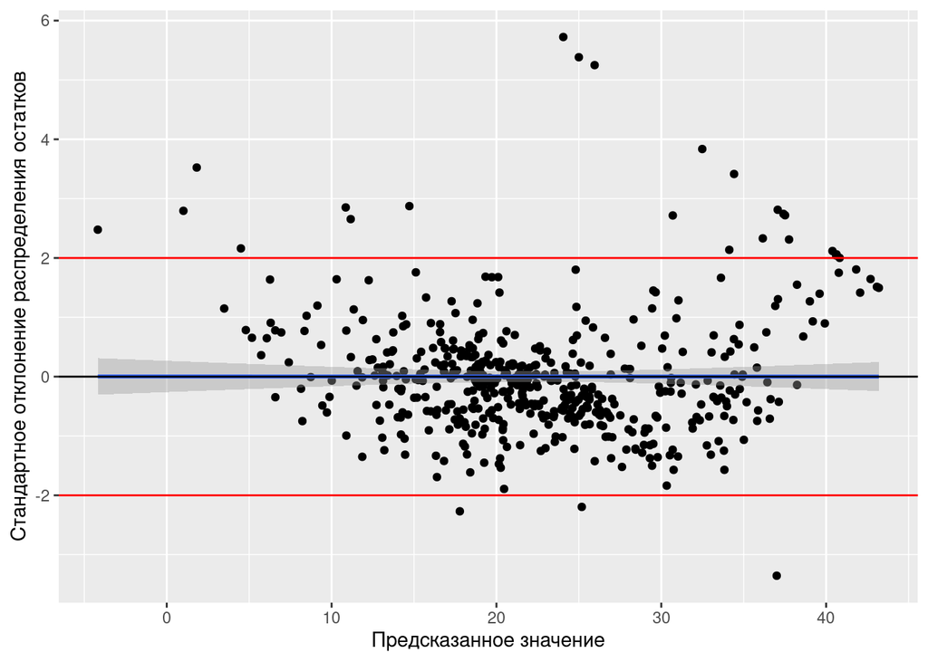

Рисунок 2. График распределения остатков полной модели

Дисперсия остатков распределена не равномерно. Наблюдаются сильные отклонения при низких и высоких значениях зависимой переменной. Некоторые наблюдения отклоняются более чем на 2 стандартных отклонения, но в целом взаимосвязь кажется линейной.

### 2.2.3 Проверка на нормальность распределения и коллинеарность предикторов

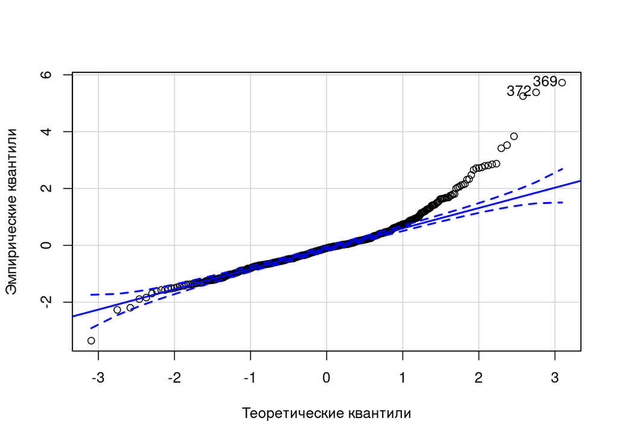

Рисунок 3. Квантиль-квантильный график для остатков полной модели

Распределение отличается от нормального. Наюлюдаются сильные отклонения от нормальности при высоких значениях зависимой переменной.

## 2.3 Предсказания модели

Построим предсказания модели для переменной **lstat**, коэффициент которой в полной модели равен **-3.77**.

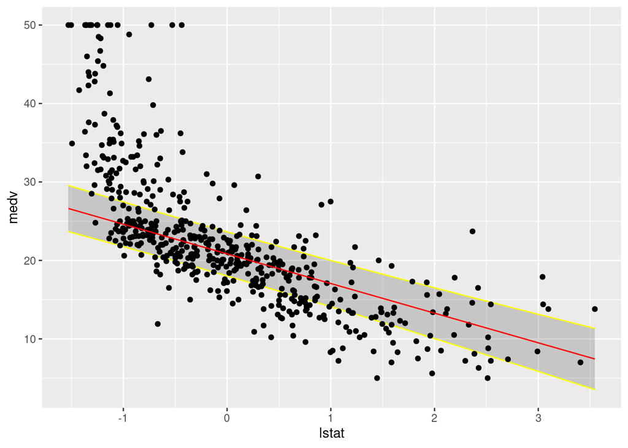

Рисунок 4. Зависимость переменной medv от переменной lstat c предсказанными моделью значениями

Из графика видно, что переменная **lstat** хорошо описывает всю модель только на небольшом интервале значений.

# 3 Поиск оптимальной модели

## 3.1 Удаление коллинеарных предикторов

Рассмотрим модель на предмет наличия коллинеарных предикторов, расчитав фактор вздутия дисперсии.

```r
VIF(model)
```

```
##              GVIF Df GVIF^(1/(2*Df))
## crim     1.811867  1        1.346056
## zn       2.496184  1        1.579932
## indus    4.370471  1        2.090567
## chas     1.101843  1        1.049687
## nox      4.672906  1        2.161691
## rm       2.007593  1        1.416896
## age      3.177556  1        1.782570
## dis      4.143583  1        2.035579
## rad     18.783126  8        1.201187
## tax      9.876853  1        3.142746
## ptratio  2.242683  1        1.497559
## black    1.352516  1        1.162977
## lstat    2.997620  1        1.731364
```

Уберём предикторы с самым большим VIF, пока не останутся только предикторы с VIF < 2.

```r
model_1 <- update(model, .~. - rad)
VIF(model_1)
```

```
##     crim       zn    indus     chas      nox       rm      age      dis
## 1.664471 2.273018 3.682265 1.061561 4.304929 1.885425 3.083009 3.954951
##      tax  ptratio    black    lstat
## 3.415289 1.734873 1.341459 2.937752
```

```r
model_2 <- update(model_1, .~. - dis)
VIF(model_2)
```

```
##     crim       zn    indus     chas      nox       rm      age      tax
## 1.638205 1.897074 3.511704 1.061233 3.949993 1.849614 2.821975 3.414851
##  ptratio    black    lstat
## 1.720096 1.340875 2.933530
```

```r
model_3 <- update(model_2, .~. - nox)
VIF(model_3)
```

```
##     crim       zn    indus     chas       rm      age      tax  ptratio
## 1.637882 1.826807 3.155735 1.057774 1.847368 2.430656 3.073277 1.504126
##    black    lstat
## 1.331457 2.920516
```

```r
model_4 <- update(model_3, .~. - indus)
VIF(model_4)
```

```
##     crim       zn     chas       rm      age      tax  ptratio    black
## 1.622496 1.695271 1.045869 1.813320 2.291640 2.209662 1.499542 1.329512
##    lstat
## 2.897706
```

```r
# model_5 <- update(model_4, .~. - lstat)
# VIF(model_5)

model_6 <- update(model_4, .~. - tax)
VIF(model_6)
```

```
##     crim       zn     chas       rm      age  ptratio    black    lstat
## 1.407383 1.684097 1.045648 1.813299 2.157710 1.351937 1.260738 2.863701
```

## 3.2 Удаление незначимых предикторов

На данный момент в нашей модели осталось 8 предикторов, однако не все предикторы могут одинаково хорошо объяснять изменчивость модели. Для нахождения незначимых предикторов воспользуемся подходом *backward selection*.

|  | Df | Sum of Sq | RSS | AIC | F value | Pr(>F) |
| --- | --- | --- | --- | --- | --- | --- |
|  | NA | NA | 12903.49 | 1656.791 | NA | NA |
| crim | 1 | 43.628508 | 12947.12 | 1656.499 | 1.6804260 | 1.954694e-01 |
| zn | 1 | 1.281683 | 12904.78 | 1654.841 | 0.0493662 | 8.242611e-01 |
| chas | 1 | 305.022183 | 13208.52 | 1666.613 | 11.7484471 | 6.594881e-04 |
| rm | 1 | 2867.797934 | 15771.29 | 1756.341 | 110.4581052 | 1.822323e-23 |
| age | 1 | 41.841861 | 12945.34 | 1656.429 | 1.6116103 | 2.048597e-01 |
| ptratio | 1 | 1246.944253 | 14150.44 | 1701.468 | 48.0281745 | 1.308804e-11 |
| black | 1 | 293.321516 | 13196.82 | 1666.164 | 11.2977761 | 8.357689e-04 |
| lstat | 1 | 2605.667248 | 15509.16 | 1747.861 | 100.3616969 | 1.219679e-21 |

Видно, что предикторы **zn, crim, age** не влияют значимо на количество объяснённой моделью изменчивости, поэтому их следует удалить.

После удаления незначимого предиктора модель имеет следующий вид:

```
##
## Call:
## lm(formula = medv ~ chas + rm + ptratio + black + lstat, data = Boston)
##
## Residuals:
##      Min       1Q   Median       3Q      Max
## -17.6281  -2.9377  -0.8882   1.5061  30.2533
##
## Coefficients:
##             Estimate Std. Error t value Pr(>|t|)
## (Intercept)  22.3032     0.2350  94.914  < 2e-16 ***
## chas1         3.3200     0.9015   3.683 0.000256 ***
## rm            3.2688     0.2951  11.076  < 2e-16 ***
## ptratio      -1.8581     0.2500  -7.432 4.67e-13 ***
## black         0.9232     0.2466   3.743 0.000203 ***
## lstat        -3.6995     0.3137 -11.792  < 2e-16 ***
## ---
## Signif. codes:  0 '***' 0.001 '**' 0.01 '*' 0.05 '.' 0.1 ' ' 1
##
## Residual standard error: 5.096 on 500 degrees of freedom
## Multiple R-squared:  0.696,  Adjusted R-squared:  0.693
## F-statistic: 228.9 on 5 and 500 DF,  p-value: < 2.2e-16
```

```r
VIF(model_7)
```

```
##     chas       rm  ptratio    black    lstat
## 1.019506 1.693576 1.215367 1.182497 1.913747
```

Видно, что VIF предиктора **lstat** стал меньше 2.

## 3.3 Диагностика модели

Проведём диагностику оптимизированной модели.

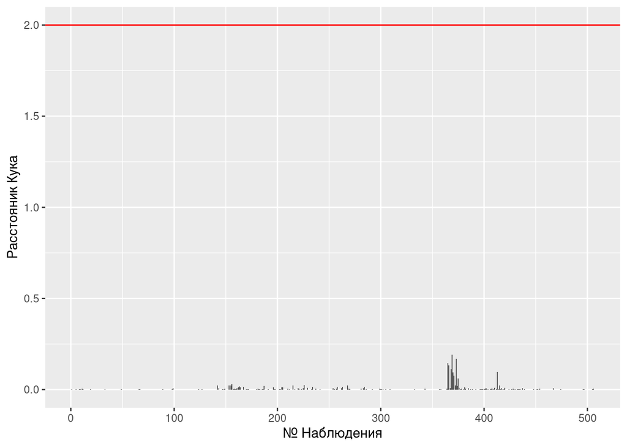

Рисунок 5. График расстояний Кука для оптимизированной модели

Влиятельные наблюдения отсутствуют.

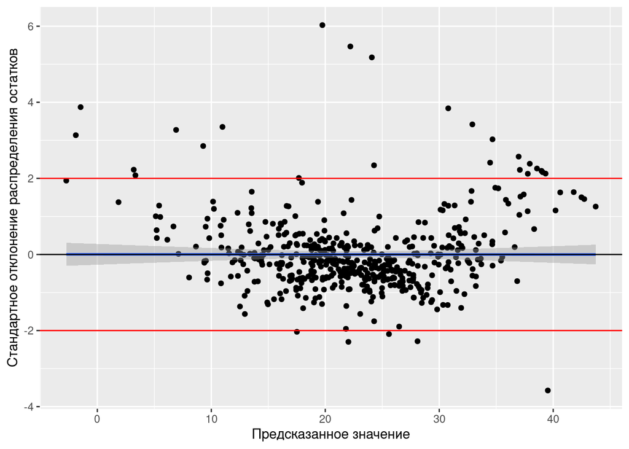

Рисунок 6. Распределение остатков для оптимизированной модели

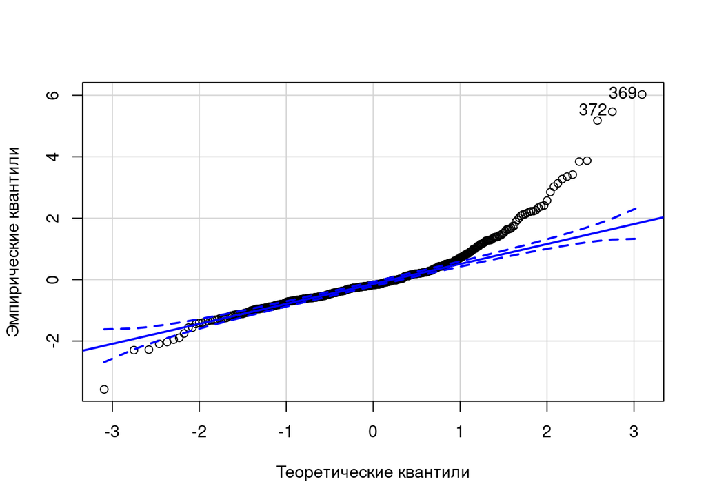

Рисунок 7. Квантиль-квантильный график для остатков оптимизированной модели

```
## [1] 369 372
```

Распределение остатков не является нормальным.

## 3.4 Задача максимизации цены дома

Ещё раз посмотрим на модель. Модель однозначно нельзя назвать полностью оптимизированной, однако нам удалось её немного улучшить. R^2 модели приблизительно равен **0.7**.

Для того, чтобы максимизировать цену за продаваемый дом, необходимо учесть на какие из значимых предикторов в реальности можно повлиять, чтобы увеличить значение зависимой переменной.

Рассмотрим предикторы по очереди:

### 3.4.2 rm

Количественная переменная *rm* показывает среднее количество комнат в доме. Её коэффициент в модели равен **3.27**, а значит также существенно оказывает влияние на зависимую переменную. Увеличение количества комнат в доме будет приводить к увеличению его стоимости.

### 3.4.3 ptratio

Количественная переменная *ptratio* показывает отношении количества учеников к количеству учителей. Её коэффициент в модели равен **-1.86**. Это значит, что более предпочтительным будет район, где на одного учителя будет приходится меньше учеников, что, возможно, повышает качество образования.

### 3.4.4 black

Количественная переменная *black* показывает преобразованные данные о проценте чернокожего населения (black = 1000(Bk - 0.63)^2, где Bk - доля чернокожего населения). Эта переменная будет оказывать одинаковое влияние на зависимую переменную при увеличении или уменьшении процента чернокожего населения, однако при уменьшении могут быть достигнуты бОльшие значения переменной *black*. Например, $1000(1 - 0.63)^2 < 1000(0 - 0.63)^2$. Таким образом можно было бы порекомендовать заказчику выбрать район с максимальным процентом белого населения, но мы не расисты и не будем так делать! Тем более, что значение коэффициента предиктора равно всего лишь **0.92** и не будет оказывать столь значительное влияние на цену.

### 3.4.5 lstat

Количественная переменная *lstat* является довольно сложной социально-экономической характеристикой, учитывающей количество взрослых без высшего образования и чернорабочих. Поскольку коэффициент в модели равен **-3.7**, данный предиктор будет оказывать наиболее сильное влияние на значение зависимой переменной. Выбор района с высокими показателями образованности и занятости населения позволит существенно повысить цену дома.

## 3.5 Итоговая рекомендация

Наиболее выгодной будет постройка дома с более, чем 8 комнатами возле реки в районе с большим количеством учителей, высокой образованностью населения и высокой квалификацией рабочих.